# AIML_ML_Project_full_code_notebook-2

## Model Performance Improvement

### Decision Tree (Pre-pruning)

**Using GridSearch for Hyperparameter tuning of our tree model**

- Hyperparameter tuning is also tricky in the sense that there is no direct way to calculate how a change in the hyperparameter value will reduce the loss of your model, so we usually resort to experimentation. Grid search Techniques applied.
- Grid search is a tuning technique that attempts to compute the optimum values of hyperparameters.
- It is an exhaustive search that is performed on a the specific parameter values of a model.
- The parameters of the estimator/model used to apply these methods are optimized by cross-validated grid-search over a parameter grid.

```python
# To tune different models
from sklearn.model_selection import GridSearchCV

# Choose the type of classifier.
estimator = DecisionTreeClassifier(random_state=1)

# Grid of parameters to choose from
parameters = {
    "class_weight": [None, "balanced"],
    "max_depth": [3,5,7,9,10],
    "max_leaf_nodes": [100, 200, 500, 1000],
    "min_samples_split": [2, 10, 50],
}

# Type of scoring used to compare parameter combinations
acc_scorer = "recall"

# Run the grid search
grid_obj = GridSearchCV(estimator, parameters, scoring=acc_scorer, cv=5)
grid_obj = grid_obj.fit(X_train, y_train)

# Set the clf to the best combination of parameters
estimator = grid_obj.best_estimator_

# Print the best parameters
print("Best parameters found:")
print(f"Max depth: {estimator.max_depth}")
print(f"Max leaf nodes: {estimator.max_leaf_nodes}")
print(f"Min samples split: {estimator.min_samples_split}")


# Fit the best algorithm to the data.
estimator.fit(X_train, y_train)
```

```
Best parameters found:
Max depth: 3
Max leaf nodes: 100
Min samples split: 2
```

```
DecisionTreeClassifier(class_weight='balanced', max_depth=3, max_leaf_nodes=100,
                       random_state=1)
```

**Checking performance on training data**

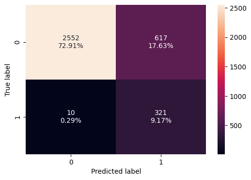

```python
# Confusion matrix for Training Data Set
confusion_matrix_sklearn(estimator, X_train, y_train)
```

```python
# Pre-Pruned Tree on Training Data Set Performance measures
decision_tree_tune_perf_train = model_performance_classification_sklearn(
    estimator, X_train, y_train
)
decision_tree_tune_perf_train
```

|  | Accuracy | Recall | Precision | F1 |
| --- | --- | --- | --- | --- |
| 0 | 0.820857 | 0.969789 | 0.342217 | 0.50591 |

**Checking performance on testing data**

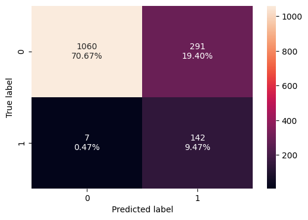

```python
# Confusion matrix for Test Data Set
confusion_matrix_sklearn(estimator, X_test, y_test)
```

```python
# Pre-Pruned Tree on Training Data Set Performance measures
decision_tree_tune_perf_test = model_performance_classification_sklearn(
    estimator, X_test, y_test
)
decision_tree_tune_perf_test
```

|  | Accuracy | Recall | Precision | F1 |
| --- | --- | --- | --- | --- |
| 0 | 0.801333 | 0.95302 | 0.327945 | 0.487973 |

**Obervations**

- The pre-pruned decision tree shows high recall on both the training (**96.98%**) and test data (**95.30%**), indicating that it effectively captures most potential loan buyers, which aligns with the campaign’s objective. This model works well on our primary metric which is recall.
- However, the precision is low on both datasets (**34.22%** on training and **32.79%** on test), suggesting that a significant portion of the predicted loan buyers are actually not interested, leading to wasted marketing efforts.
- The accuracy is around **82.1%** on training and **80.1%** on test, while the F1 score remains moderate (**0.5059 on training and 0.4879 on test**), showing that the model may benefit from further tuning or pruning to improve precision without sacrificing recall.

**Visualizing the Decision Tree**

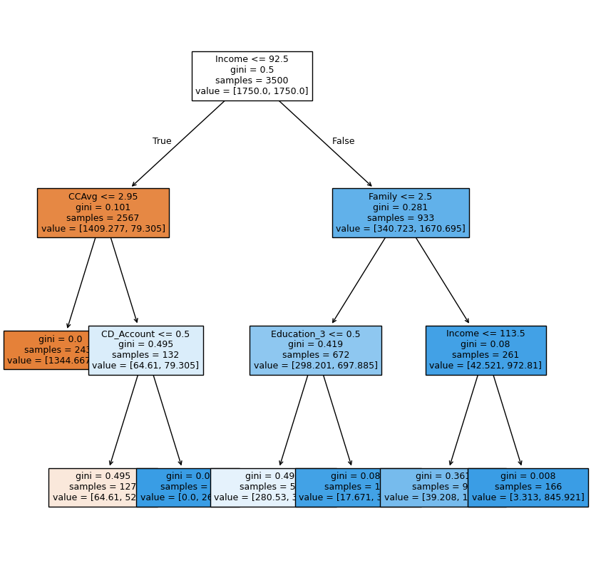

```python
plt.figure(figsize=(10, 10))
# plotting the decision tree
out = tree.plot_tree(
    estimator,
    feature_names=feature_names,
    filled=True,
    fontsize=9,
    node_ids=False,
    class_names=None,
)
# below code will add arrows to the decision tree split if they are missing
for o in out:
    arrow = o.arrow_patch
    if arrow is not None:
        arrow.set_edgecolor("black")
        arrow.set_linewidth(1)
plt.show()
```

- This is a far less complex tree than the previous default one.

```python
# Text report showing the rules of a decision tree -

print(tree.export_text(estimator, feature_names=feature_names, show_weights=True))
```

```
|--- Income <= 92.50
|   |--- CCAvg <= 2.95
|   |   |--- weights: [1344.67, 0.00] class: 0
|   |--- CCAvg >  2.95
|   |   |--- CD_Account <= 0.50
|   |   |   |--- weights: [64.61, 52.87] class: 0
|   |   |--- CD_Account >  0.50
|   |   |   |--- weights: [0.00, 26.44] class: 1
|--- Income >  92.50
|   |--- Family <= 2.50
|   |   |--- Education_3 <= 0.50
|   |   |   |--- weights: [280.53, 322.51] class: 1
|   |   |--- Education_3 >  0.50
|   |   |   |--- weights: [17.67, 375.38] class: 1
|   |--- Family >  2.50
|   |   |--- Income <= 113.50
|   |   |   |--- weights: [39.21, 126.89] class: 1
|   |   |--- Income >  113.50
|   |   |   |--- weights: [3.31, 845.92] class: 1
```

```python
# importance of features in the tree building ( The importance of a feature is computed as the
# (normalized) total reduction of the criterion brought by that feature. It is also known as the Gini importance )

print(
    pd.DataFrame(
        estimator.feature_importances_, columns=["Imp"], index=X_train.columns
    ).sort_values(by="Imp", ascending=False)
)
```

```
                         Imp
Income              0.812063
Education_3         0.065074
CCAvg               0.061131
Family              0.051625
CD_Account          0.010107
ZIPCode_93          0.000000
Education_2         0.000000
ZIPCode_96          0.000000
ZIPCode_95          0.000000
ZIPCode_94          0.000000
Age                 0.000000
ZIPCode_92          0.000000
ZIPCode_91          0.000000
Online              0.000000
Securities_Account  0.000000
Mortgage            0.000000
CreditCard          0.000000
```

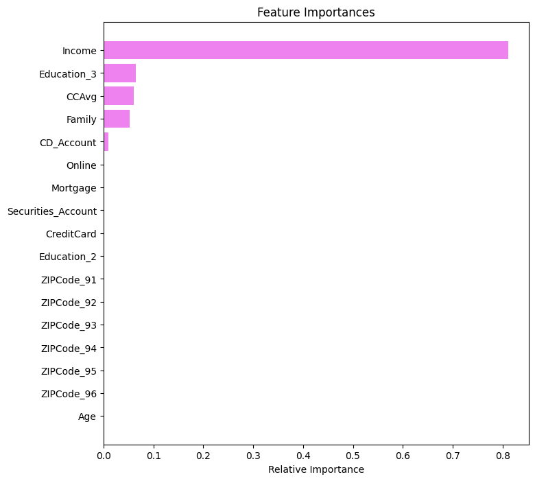

```python
# importance of features in the tree building
importances = estimator.feature_importances_
indices = np.argsort(importances)

plt.figure(figsize=(8, 8))
plt.title("Feature Importances")
plt.barh(range(len(indices)), importances[indices], color="violet", align="center")
plt.yticks(range(len(indices)), [feature_names[i] for i in indices])
plt.xlabel("Relative Importance")
plt.show()
```

**Observations**

- The feature importance chart reveals that `Income` is by far the most influential factor in predicting personal loan acceptance, with a significantly higher relative importance than any other attribute. This suggests that higher income levels strongly correlate with a customer’s likelihood to accept a personal loan.
- Other factors like `Education` (level 3), `CCAvg` (average credit card spending), and `Family` size have some influence, but their impact is minimal compared to Income.
- Variables such as `CDAccount` and `Online` have negligible importance, indicating they play little to no role in predicting loan acceptance in the current model. This insight can guide the marketing team to prioritize targeting high-income customers, as they are more likely to respond positively to loan offers.

#### Post-pruning

- The Post-Pruned Decision Tree is a refined model designed to balance simplicity and performance. By reducing overfitting and enhancing generalization, it ensures consistent and reliable predictions.

```python
# Create an instance of the decision tree model
clf = DecisionTreeClassifier(random_state=1, class_weight="balanced")
# Compute the cost complexity pruning path for the model using the training data
path = clf.cost_complexity_pruning_path(X_train, y_train)
#Extract the  alphas and total impurities
ccp_alphas, impurities = abs(path.ccp_alphas), path.impurities
```

Next, we train a decision tree using the effective alphas. The last value in `ccp_alphas` is the alpha value that prunes the whole tree, leaving the tree, `clfs[-1]`, with one node.

```python
# Initialize an empty list to store the decision tree classifiers
clfs = []
for ccp_alpha in ccp_alphas:
    # Create a decision tree classifier with the current alpha value
    clf = DecisionTreeClassifier(
        random_state=1, ccp_alpha=ccp_alpha, class_weight="balanced"
    )
    # Fit the classifier to the training data
    clf.fit(X_train, y_train)
    # Append the trained classifier to the list
    clfs.append(clf)
print(
    "Number of nodes in the last tree is: {} with ccp_alpha: {}".format(
        clfs[-1].tree_.node_count, ccp_alphas[-1]
    )
)
```

```
Number of nodes in the last tree is: 1 with ccp_alpha: 0.2953792759992314
```

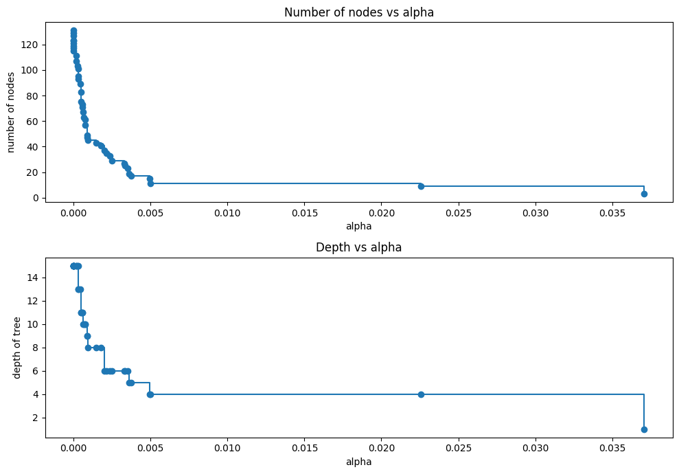

```python
# Remove the last classifier and corresponding ccp_alpha value from the lists
clfs = clfs[:-1]
ccp_alphas = ccp_alphas[:-1]

# Extract the number of nodes in each tree classifier
node_counts = [clf.tree_.node_count for clf in clfs]

# Extract the maximum depth of each tree classifier
depth = [clf.tree_.max_depth for clf in clfs]

fig, ax = plt.subplots(2, 1, figsize=(10, 7))

# Plot the number of nodes versus ccp_alphas on the first subplot
ax[0].plot(ccp_alphas, node_counts, marker="o", drawstyle="steps-post")
ax[0].set_xlabel("alpha")
ax[0].set_ylabel("number of nodes")
ax[0].set_title("Number of nodes vs alpha")

# Plot the depth of tree versus ccp_alphas on the second subplot
ax[1].plot(ccp_alphas, depth, marker="o", drawstyle="steps-post")
ax[1].set_xlabel("alpha")
ax[1].set_ylabel("depth of tree")
ax[1].set_title("Depth vs alpha")

# Adjust the layout of the subplots to avoid overlap
fig.tight_layout()
```

**Recall vs alpha for training and testing sets**

```python
# Initialize a list to store recall scores for training data
recall_train = []
for clf in clfs:
    # Predict the target variable using the current classifier on training data
    pred_train = clf.predict(X_train)
    # Calculate the recall score for the predictions on training data
    values_train = recall_score(y_train, pred_train)
    # Append the recall score to the list
    recall_train.append(values_train)
```

```python
# Initialize a list to store recall scores for testing data
recall_test = []
for clf in clfs:
    # Predict the target variable using the current classifier on testing data
    pred_test = clf.predict(X_test)
    # Calculate the recall score for the predictions on testing data
    values_test = recall_score(y_test, pred_test)
    # Append the recall score to the list
    recall_test.append(values_test)
```

```python
# Calculate and store the training scores (accuracy) for each classifier in the list of classifiers (clfs)
train_scores = [clf.score(X_train, y_train) for clf in clfs]
# Calculate and store the testing scores (accuracy) for each classifier in the list of classifiers (clfs)
test_scores = [clf.score(X_test, y_test) for clf in clfs]
```

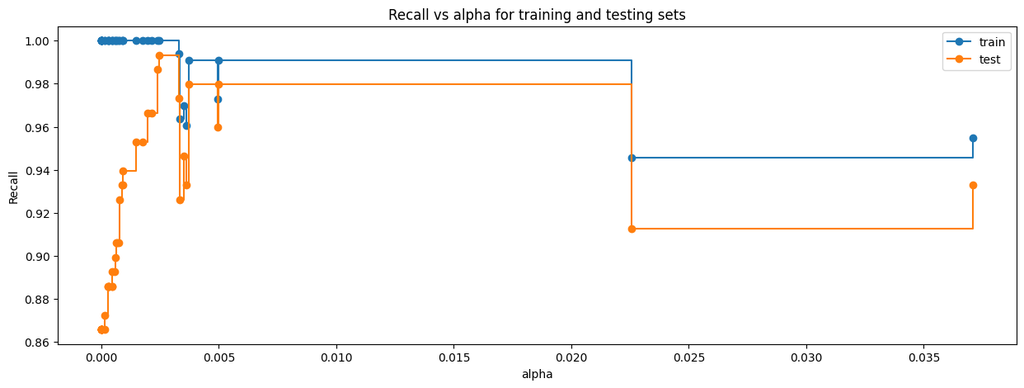

```python
# Plotting the recall vs alpha for training and testing scores
fig, ax = plt.subplots(figsize=(15, 5))
ax.set_xlabel("alpha")
ax.set_ylabel("Recall")
ax.set_title("Recall vs alpha for training and testing sets")
ax.plot(
    ccp_alphas, recall_train, marker="o", label="train", drawstyle="steps-post",
)
ax.plot(ccp_alphas, recall_test, marker="o", label="test", drawstyle="steps-post")
ax.legend()
plt.show()
```

```python
# Displaying the ccp_alphas
ccp_alphas
```

```
array([0.00000000e+00, 3.85372460e-19, 4.72957111e-19, 5.25507901e-19,
       5.25507901e-19, 7.70744921e-19, 1.05101580e-18, 1.57652370e-18,
       1.25780554e-17, 1.52470014e-04, 1.56755168e-04, 2.76101414e-04,
       2.85714286e-04, 3.03662934e-04, 3.09099901e-04, 4.49842555e-04,
       4.66332895e-04, 4.71488686e-04, 5.51763920e-04, 5.90028518e-04,
       6.29249653e-04, 6.61643889e-04, 7.53816671e-04, 7.58064917e-04,
       8.72807968e-04, 8.98180363e-04, 9.26929393e-04, 1.46181515e-03,
       1.76801849e-03, 1.98173011e-03, 2.15041375e-03, 2.37580862e-03,
       2.47265988e-03, 3.29725468e-03, 3.34449290e-03, 3.50379426e-03,
       3.60293208e-03, 3.72968952e-03, 4.94145660e-03, 4.97098717e-03,
       2.25579227e-02, 3.70874922e-02])
```

```python
# creating the best model where we get highest recall_test score
index= np.argmax(recall_test[::-1][1:])
best_model =clfs[::-1][1:][index]
```

```python
#Fit the train data with the best_model
best_model.fit(X_train, y_train)
```

```
DecisionTreeClassifier(ccp_alpha=0.0024726598786422157, class_weight='balanced',
                       random_state=1)
```

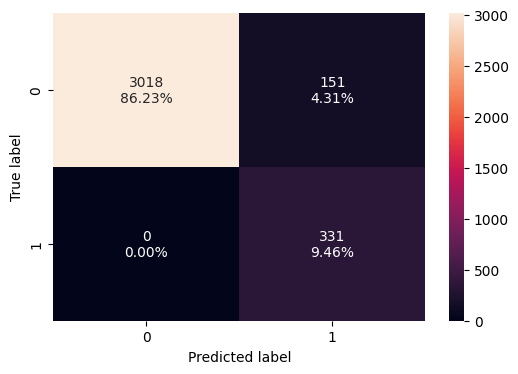

```python
# Confusion matrix for post-pruned tree of training data
confusion_matrix_sklearn(best_model, X_train, y_train)
```

```python
# Get the performance measures of post-pruned tree for training data
decision_tree_post_perf_train = model_performance_classification_sklearn(
    best_model, X_train, y_train
)
decision_tree_post_perf_train
```

|  | Accuracy | Recall | Precision | F1 |
| --- | --- | --- | --- | --- |
| 0 | 0.956857 | 1.0 | 0.686722 | 0.814268 |

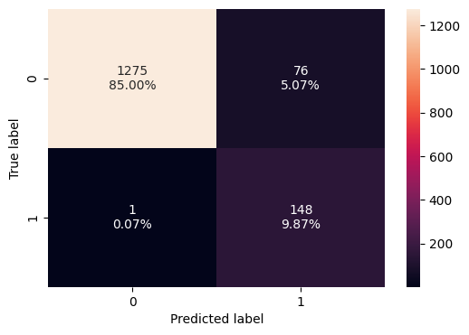

```python
# Confusion matrix for post-pruned tree of test data
confusion_matrix_sklearn(best_model, X_test, y_test)
```

```python
#Get the performance measures of post-pruned tree for test data
decision_tree_post_test = model_performance_classification_sklearn(
    best_model, X_test, y_test
)
decision_tree_post_test
```

|  | Accuracy | Recall | Precision | F1 |
| --- | --- | --- | --- | --- |
| 0 | 0.948667 | 0.993289 | 0.660714 | 0.793566 |

**Observations from post pruned tree perfromance**

**Training Data Performance:**

- The post-pruned tree performs exceptionally well on the training data, achieving an accuracy of **95.69%**. It has perfect recall (**100%**), meaning the model successfully identifies all potential loan buyers, ensuring no missed opportunities.
- However, the precision is moderate at **68.67%**, indicating that while the model captures all buyers, some predictions are False Positives, leading to unnecessary marketing efforts.
- The F1 score of **81.43%** reflects a good balance between recall and precision.

**Testing Data Performance**

- On the test data, the model maintains strong generalization with an accuracy of **94.87%**. Recall remains very high at **99.32%**, effectively identifying almost all loan buyers.
- Precision is consistent at **66.07%**, showing a similar level of False Positives as in the training data.
- The F1 score of **79.35%** confirms that the model balances recall and precision well, making it reliable for identifying potential customers while keeping marketing inefficiencies reasonable.

#### Visualizing Decision Tree

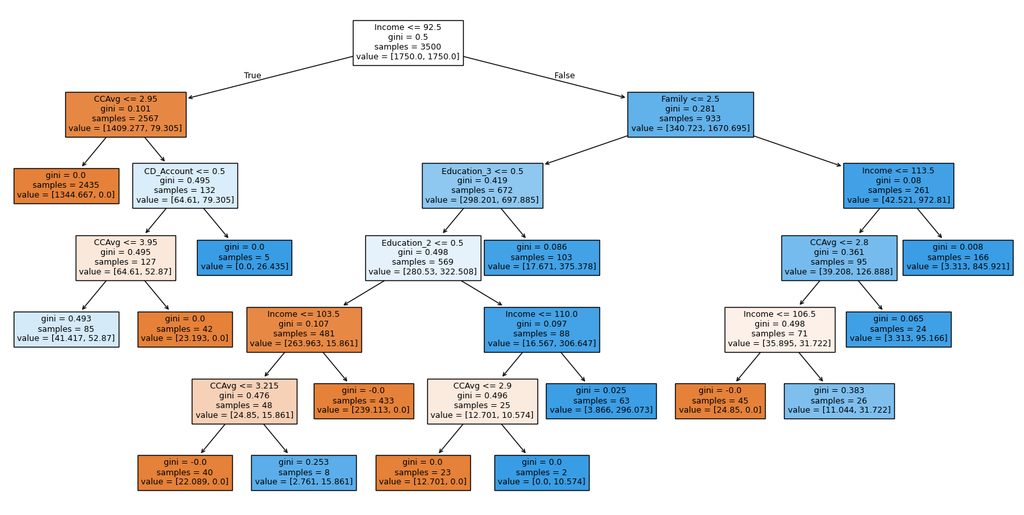

```python
plt.figure(figsize=(20, 10))

# plotting the decision tree
out = tree.plot_tree(
    best_model,
    feature_names=feature_names,
    filled=True,
    fontsize=9,
    node_ids=False,
    class_names=None,
)
# add arrows to the decision tree splits if they are missing
for o in out:
    arrow = o.arrow_patch
    if arrow is not None:
        arrow.set_edgecolor("black")
        arrow.set_linewidth(1)
plt.show()
```

```python
# Text report showing the rules of a decision tree -

print(tree.export_text(best_model, feature_names=feature_names, show_weights=True))
```

```
|--- Income <= 92.50
|   |--- CCAvg <= 2.95
|   |   |--- weights: [1344.67, 0.00] class: 0
|   |--- CCAvg >  2.95
|   |   |--- CD_Account <= 0.50
|   |   |   |--- CCAvg <= 3.95
|   |   |   |   |--- weights: [41.42, 52.87] class: 1
|   |   |   |--- CCAvg >  3.95
|   |   |   |   |--- weights: [23.19, 0.00] class: 0
|   |   |--- CD_Account >  0.50
|   |   |   |--- weights: [0.00, 26.44] class: 1
|--- Income >  92.50
|   |--- Family <= 2.50
|   |   |--- Education_3 <= 0.50
|   |   |   |--- Education_2 <= 0.50
|   |   |   |   |--- Income <= 103.50
|   |   |   |   |   |--- CCAvg <= 3.21
|   |   |   |   |   |   |--- weights: [22.09, 0.00] class: 0
|   |   |   |   |   |--- CCAvg >  3.21
|   |   |   |   |   |   |--- weights: [2.76, 15.86] class: 1
|   |   |   |   |--- Income >  103.50
|   |   |   |   |   |--- weights: [239.11, 0.00] class: 0
|   |   |   |--- Education_2 >  0.50
|   |   |   |   |--- Income <= 110.00
|   |   |   |   |   |--- CCAvg <= 2.90
|   |   |   |   |   |   |--- weights: [12.70, 0.00] class: 0
|   |   |   |   |   |--- CCAvg >  2.90
|   |   |   |   |   |   |--- weights: [0.00, 10.57] class: 1
|   |   |   |   |--- Income >  110.00
|   |   |   |   |   |--- weights: [3.87, 296.07] class: 1
|   |   |--- Education_3 >  0.50
|   |   |   |--- weights: [17.67, 375.38] class: 1
|   |--- Family >  2.50
|   |   |--- Income <= 113.50
|   |   |   |--- CCAvg <= 2.80
|   |   |   |   |--- Income <= 106.50
|   |   |   |   |   |--- weights: [24.85, 0.00] class: 0
|   |   |   |   |--- Income >  106.50
|   |   |   |   |   |--- weights: [11.04, 31.72] class: 1
|   |   |   |--- CCAvg >  2.80
|   |   |   |   |--- weights: [3.31, 95.17] class: 1
|   |   |--- Income >  113.50
|   |   |   |--- weights: [3.31, 845.92] class: 1
```

**Decision Rules from the final model(Post-Pruned)**

**Key Takeaways:**

```python
#Retrieve the important features
importances = best_model.feature_importances_
indices = np.argsort(importances)
```

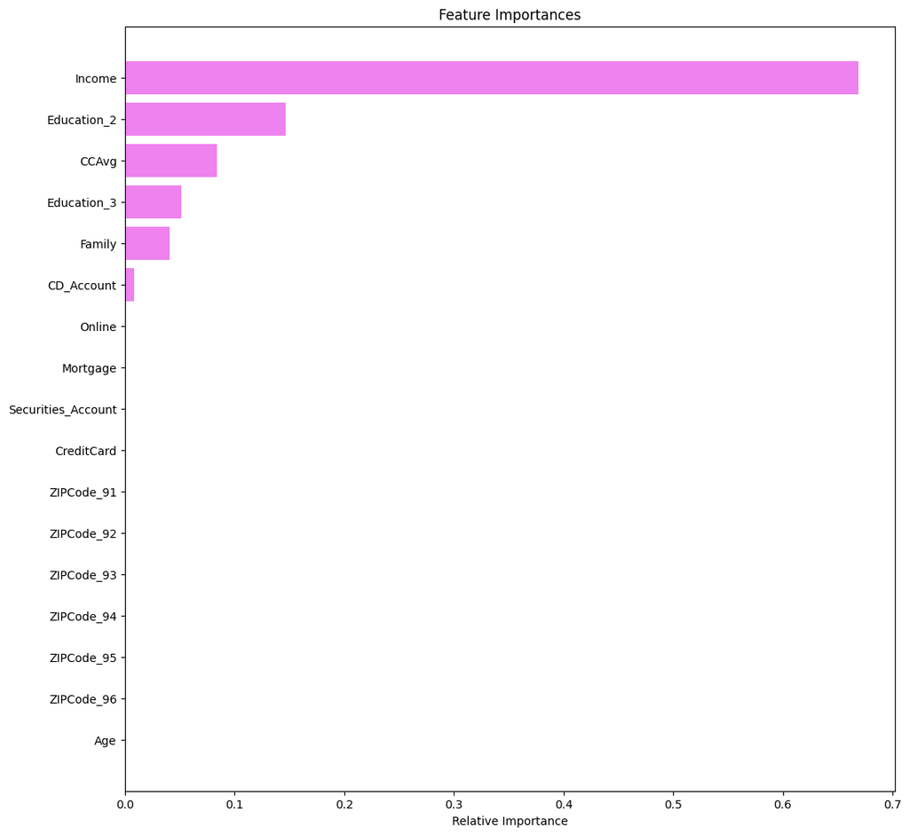

```python
#plotting the importance features
plt.figure(figsize=(12, 12))
plt.title("Feature Importances")
plt.barh(range(len(indices)), importances[indices], color="violet", align="center")
plt.yticks(range(len(indices)), [feature_names[i] for i in indices])
plt.xlabel("Relative Importance")
plt.show()
```

**Obeservations on Important Features of Post Pruned Tree**

- `Income` remains the most significant predictor for personal loan acceptance, with a dominant relative importance compared to all other features. This reinforces that higher-income customers are strongly associated with loan acceptance.
- `Education (level 2)` and `CCAvg` (average credit card spending) emerge as the next most influential factors, indicating that customers with moderate educational levels and higher credit card spending are also more likely to accept a loan.
- `Education (level 3)` and `Family` size have a smaller but noticeable influence, suggesting that advanced education and family size play a secondary role in determining loan acceptance.
- Features like CD Account, Online usage, and Mortgage have minimal importance, indicating that these variables do not significantly impact the model's predictions.
- Geographic features (ZIP Codes) and Age contribute negligibly, suggesting that location and age are not strong predictors of personal loan acceptance in this scenario.

## Model Performance Comparison and Final Model Selection

#### Training performance comparison

```python
# training performance comparison

models_train_comp_df = pd.concat(
    [decision_tree_perf_train.T, decision_tree_tune_perf_train.T, decision_tree_post_perf_train.T], axis=1,
)
models_train_comp_df.columns = ["Decision Tree (sklearn default)", "Decision Tree (Pre-Pruning)", "Decision Tree (Post-Pruning)"]
print("Training performance comparison:")
models_train_comp_df
```

```
Training performance comparison:
```

|  | Decision Tree (sklearn default) | Decision Tree (Pre-Pruning) | Decision Tree (Post-Pruning) |
| --- | --- | --- | --- |
| Accuracy | 1.0 | 0.820857 | 0.956857 |
| Recall | 1.0 | 0.969789 | 1.000000 |
| Precision | 1.0 | 0.342217 | 0.686722 |
| F1 | 1.0 | 0.505910 | 0.814268 |

#### Testing performance comparison

```python
# testing performance comparison

models_test_comp_df = pd.concat(
    [decision_tree_perf_test.T, decision_tree_tune_perf_test.T, decision_tree_post_test.T], axis=1,
)
models_test_comp_df.columns = ["Decision Tree (sklearn default)", "Decision Tree (Pre-Pruning)", "Decision Tree (Post-Pruning)"]
print("Test set performance comparison:")
models_test_comp_df
```

```
Test set performance comparison:
```

|  | Decision Tree (sklearn default) | Decision Tree (Pre-Pruning) | Decision Tree (Post-Pruning) |
| --- | --- | --- | --- |
| Accuracy | 0.986000 | 0.801333 | 0.948667 |
| Recall | 0.932886 | 0.953020 | 0.993289 |
| Precision | 0.926667 | 0.327945 | 0.660714 |
| F1 | 0.929766 | 0.487973 | 0.793566 |

**Observations on Model Comparisions**

## Actionable Insights and Business Recommendations

#### What recommedations would you suggest to the bank?

- **Income as a Primary Indicator:** If income is one of the top features, target higher-income customers, as they may have greater capacity and interest in taking on a personal loan. Tailor loan products and marketing messages to appeal to this demographic.
- **Targeted Campaign with Post-Pruned Model:** Utilize the Decision Tree with post-pruning for identifying potential customers. Its high recall ensures that most potential loan customers are accurately captured, minimizing missed opportunities.
- **Focus on High-Recall Strategies:** Since the main goal is to convert liability customers into loan customers, emphasize marketing strategies that align with high-recall outcomes. This could involve offering personalized loan products tailored to the identified segments.
- **Monitor and Optimize False Positives:** While maximizing recall, manage the trade-off with precision. Use insights from the model to refine targeting criteria, ensuring resources are efficiently allocated to those more likely to convert.
- The post-pruned decision tree model shows strong potential in identifying prospective loan customers with high recall. However, due to lower precision, the bank should pair the model's insights with targeted marketing strategies to improve precision and ensure cost-effective outreach.
- By targeting high-income, higher average credit card, and Customers with advanced (Level 3) or graduate (Level 2) education levels and leveraging the insights from the predictive model(post-pruned), the marketing team can effectively design a campaign that drives loan conversions while minimizing wasted efforts.
- **Continuous Model Evaluation:** Regularly evaluate the chosen model's performance on new campaigns. This will enable ongoing optimization of marketing strategies based on real-world outcomes, ensuring sustained effectiveness in customer conversion.

## **Conclusions**

- The post-pruned decision tree model is a powerful tool for identifying potential loan customers, leveraging its high recall to ensure minimal missed opportunities in customer targeting. By focusing on high-income customers, individuals with higher credit card spending, and those with advanced education levels, the bank can craft highly targeted campaigns that maximize loan conversions. To address the trade-off with precision, refining targeting criteria and continuously monitoring the model’s performance will help optimize marketing efforts, ensuring both effectiveness and cost efficiency over time.

### Predicting on a single data point using Post-Pruned model

```python
%%time
# choosing a data point
applicant_details = X_test.iloc[:1, :]
# making a prediction
approval_prediction = best_model.predict(applicant_details)
print(approval_prediction)
```

```
[0]
CPU times: user 9.04 ms, sys: 0 ns, total: 9.04 ms
Wall time: 20.5 ms
```

- The above candidate is not approved for the Personal Loan

```python
# making a prediction
approval_likelihood = best_model.predict_proba(applicant_details)

print(approval_likelihood[0, 1])
```

```
0.0
```